# ship_study.csv

## age

| Feature | Result |
| --- | --- |
| Variable type | integer |
| Number of missing obs. | 0 (0 %) |
| Number of unique values | 64 |
| Median | 50 |
| 1st and 3rd quartiles | 36; 63 |
| Min. and max. | 19; 82 |

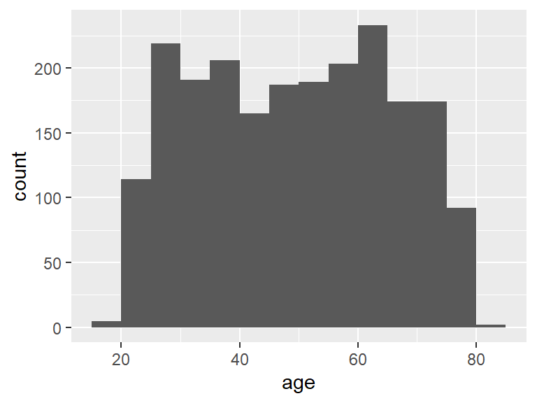

## sex

- Note that this variable is treated as a factor variable below, as it only takes a few unique values.

| Feature | Result |
| --- | --- |
| Variable type | integer |
| Number of missing obs. | 0 (0 %) |
| Number of unique values | 2 |
| Mode | “2” |
| Reference category | 1 |

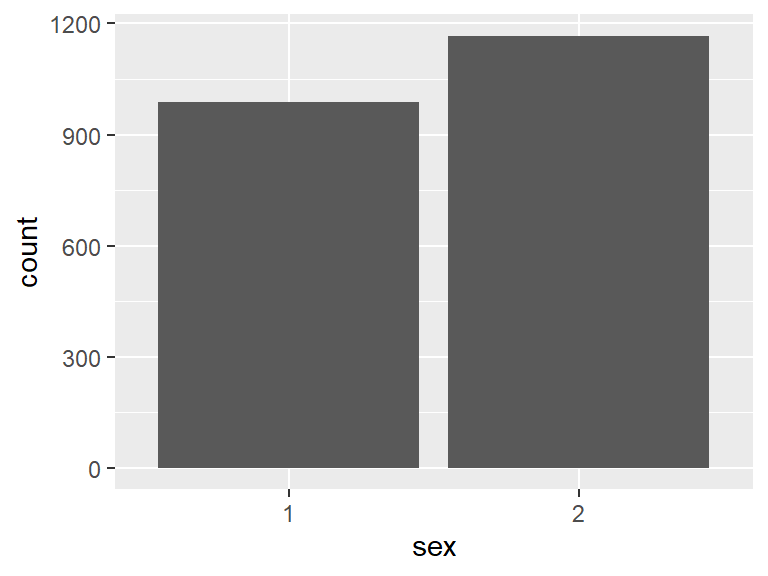

## obs_bp

| Feature | Result |
| --- | --- |
| Variable type | integer |
| Number of missing obs. | 0 (0 %) |
| Number of unique values | 11 |
| Median | 4 |
| 1st and 3rd quartiles | 4; 7 |
| Min. and max. | 1; 99902 |

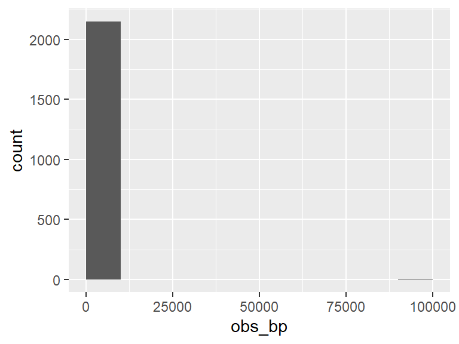

- Note that the following possible outlier values were detected: "1", "3", "99902".

## obs_soma

| Feature | Result |
| --- | --- |
| Variable type | integer |
| Number of missing obs. | 0 (0 %) |
| Number of unique values | 9 |
| Median | 5 |
| 1st and 3rd quartiles | 4; 7 |
| Min. and max. | 1; 99902 |

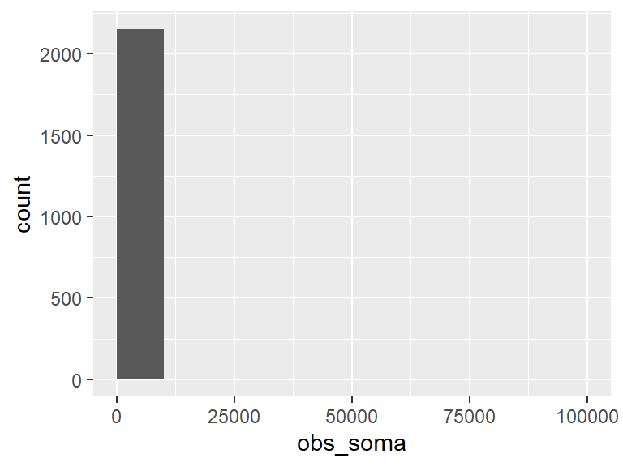

- Note that the following possible outlier values were detected: "1", "2", "99902".

## obs_int

| Feature | Result |
| --- | --- |
| Variable type | integer |
| Number of missing obs. | 0 (0 %) |
| Number of unique values | 14 |
| Median | 3 |
| 1st and 3rd quartiles | 2; 11 |
| Min. and max. | 1; 99900 |

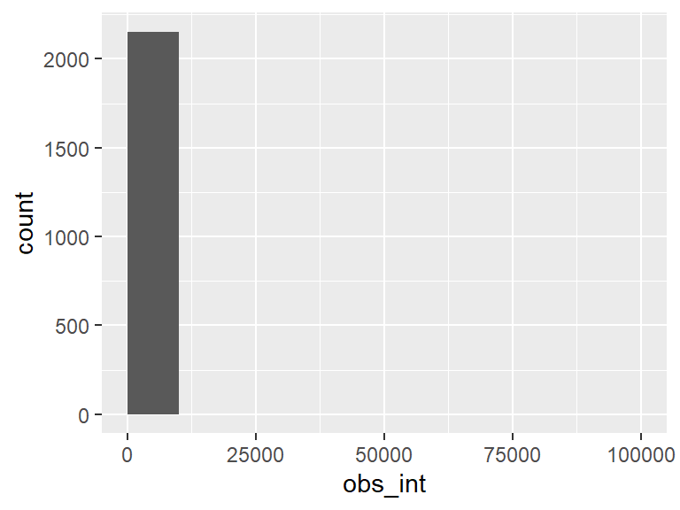

- Note that the following possible outlier values were detected: "1", "99900".

## dev_bp

| Feature | Result |
| --- | --- |
| Variable type | integer |
| Number of missing obs. | 0 (0 %) |
| Number of unique values | 12 |
| Median | 15 |
| 1st and 3rd quartiles | 10; 18 |
| Min. and max. | 7; 99902 |

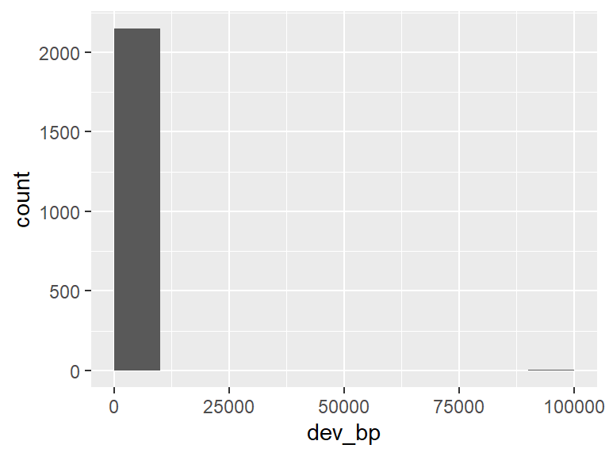

- Note that the following possible outlier values were detected: "99902".

## dev_length

- Note that this variable is treated as a factor variable below, as it only takes a few unique values.

| Feature | Result |
| --- | --- |
| Variable type | integer |
| Number of missing obs. | 0 (0 %) |
| Number of unique values | 4 |
| Mode | “3” |
| Reference category | 3 |

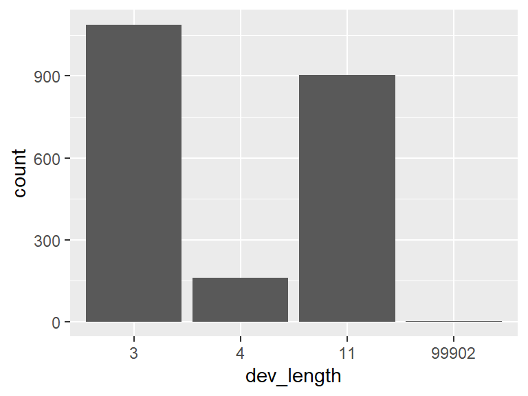

- Note that the following levels have at most five observations: "99902".

## dev_weight

- Note that this variable is treated as a factor variable below, as it only takes a few unique values.

| Feature | Result |
| --- | --- |
| Variable type | integer |
| Number of missing obs. | 0 (0 %) |
| Number of unique values | 4 |
| Mode | “1” |
| Reference category | 1 |

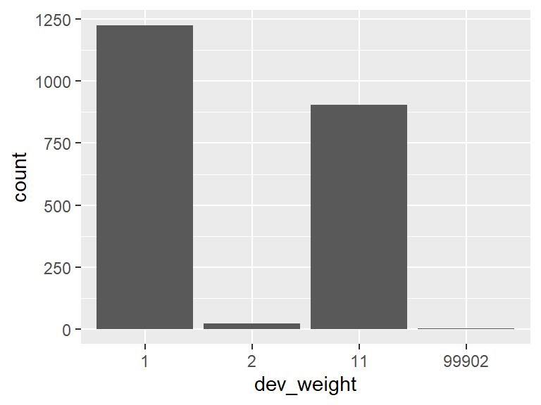

- Note that the following levels have at most five observations: "99902".

## sbp1

| Feature | Result |
| --- | --- |
| Variable type | integer |
| Number of missing obs. | 2 (0.09 %) |
| Number of unique values | 125 |
| Median | 137 |
| 1st and 3rd quartiles | 123; 153 |
| Min. and max. | 83; 253 |

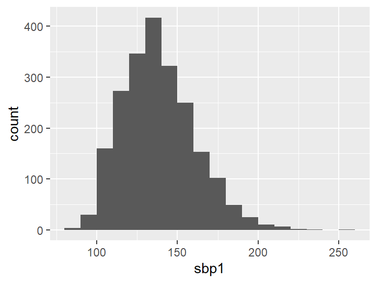

- Note that the following possible outlier values were detected: "83", "87", "88", "210", "211", "214", "215", "220", "222", "226", "238", "253".

## sbp2

| Feature | Result |
| --- | --- |
| Variable type | integer |
| Number of missing obs. | 6 (0.28 %) |
| Number of unique values | 123 |
| Median | 134 |
| 1st and 3rd quartiles | 120; 150 |
| Min. and max. | 83; 258 |

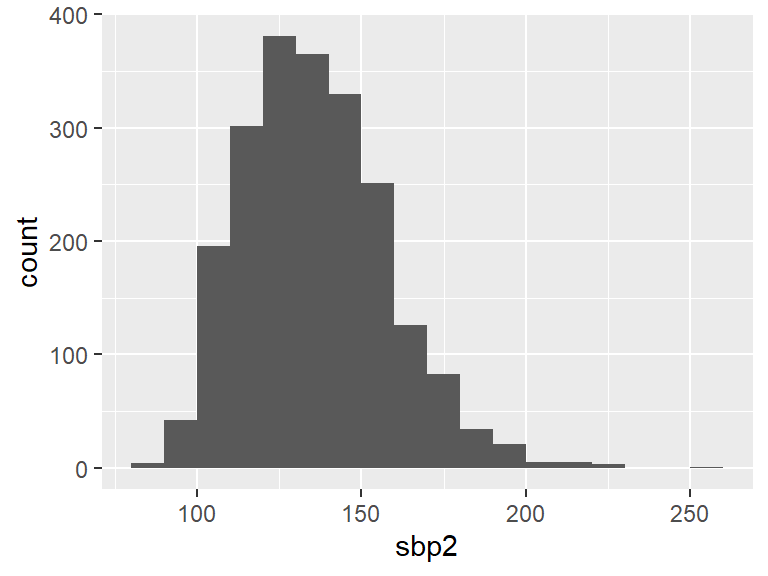

- Note that the following possible outlier values were detected: "83", "84", "87", "211", "212", "214", "216", "218", "228", "229", "230", "258".

## dbp1

| Feature | Result |
| --- | --- |
| Variable type | integer |
| Number of missing obs. | 2 (0.09 %) |
| Number of unique values | 75 |
| Median | 84 |
| 1st and 3rd quartiles | 76; 92 |
| Min. and max. | 53; 198 |

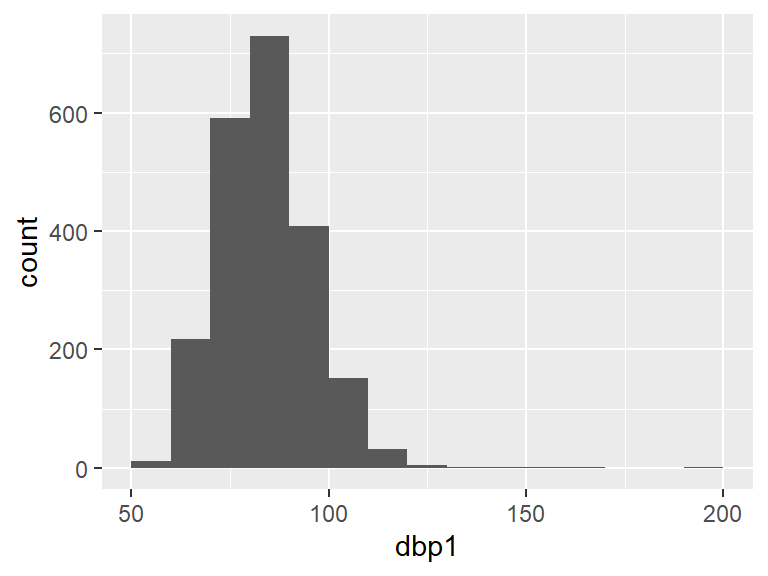

- Note that the following possible outlier values were detected: "117", "118", "119", "120", "121", "125", "126", "128", "136", "141", "153", "164", "198".

## dbp2

| Feature | Result |
| --- | --- |
| Variable type | integer |
| Number of missing obs. | 6 (0.28 %) |
| Number of unique values | 71 |
| Median | 83 |
| 1st and 3rd quartiles | 75; 91 |
| Min. and max. | 55; 151 |

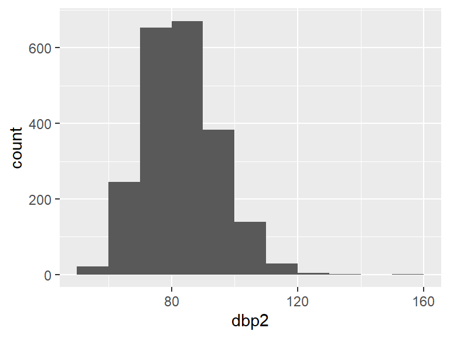

- Note that the following possible outlier values were detected: "120", "121", "122", "123", "130", "132", "151".